# Metagenomic Insights into Type 2 Diabetes A Multivariate Analysis in R

# 4. Results

## 4.1 Data acquisition

We extract the data from the article using the `curatedMetagenomicData` function. Specifically, we are interested in the **summarizedExperiment** object, which contains the metadata (including patient information) and the assays matrix (containing all the quantifications).

```r
#Data acquisition
qin_data_list <- curatedMetagenomicData("2021-10-14.QinJ_2012.relative_abundance", dryrun = FALSE)
```

```
##
## $`2021-10-14.QinJ_2012.relative_abundance`
## dropping rows without rowTree matches:
##   k__Bacteria|p__Actinobacteria|c__Coriobacteriia|o__Coriobacteriales|f__Atopobiaceae|g__Olsenella|s__Olsenella_profusa
##   k__Bacteria|p__Actinobacteria|c__Coriobacteriia|o__Coriobacteriales|f__Coriobacteriaceae|g__Collinsella|s__Collinsella_stercoris
##   k__Bacteria|p__Firmicutes|c__Bacilli|o__Bacillales|f__Bacillales_unclassified|g__Gemella|s__Gemella_bergeri
##   k__Bacteria|p__Firmicutes|c__Bacilli|o__Lactobacillales|f__Carnobacteriaceae|g__Granulicatella|s__Granulicatella_elegans
##   k__Bacteria|p__Firmicutes|c__Clostridia|o__Clostridiales|f__Ruminococcaceae|g__Ruminococcus|s__Ruminococcus_champanellensis
##   k__Bacteria|p__Firmicutes|c__Erysipelotrichia|o__Erysipelotrichales|f__Erysipelotrichaceae|g__Bulleidia|s__Bulleidia_extructa
##   k__Bacteria|p__Proteobacteria|c__Betaproteobacteria|o__Burkholderiales|f__Sutterellaceae|g__Sutterella|s__Sutterella_parvirubra
##   k__Bacteria|p__Synergistetes|c__Synergistia|o__Synergistales|f__Synergistaceae|g__Cloacibacillus|s__Cloacibacillus_evryensis
```

```r
# SummarizedExperiment extraction
qin_tse <- qin_data_list[[1]]

#Check
head(colData(qin_tse))
```

```
## DataFrame with 6 rows and 25 columns
##          study_name  subject_id   body_site antibiotics_current_use
##         <character> <character> <character>             <character>
## CON-001   QinJ_2012     CON-001       stool                      no
## CON-002   QinJ_2012     CON-002       stool                      no
## CON-003   QinJ_2012     CON-003       stool                      no
## CON-004   QinJ_2012     CON-004       stool                      no
## CON-005   QinJ_2012     CON-005       stool                      no
## CON-006   QinJ_2012     CON-006       stool                      no
##         study_condition     disease       age age_category      gender
##             <character> <character> <integer>  <character> <character>
## CON-001         control     healthy        21        adult      female
## CON-002         control     healthy        53        adult      female
## CON-003         control     healthy        61        adult      female
## CON-004         control     healthy        55        adult      female
## CON-005         control     healthy        53        adult      female
## CON-006         control     healthy        52        adult      female
##             country non_westernized sequencing_platform        PMID
##         <character>     <character>         <character> <character>
## CON-001         CHN              no       IlluminaHiSeq    23023125
## CON-002         CHN              no       IlluminaHiSeq    23023125
## CON-003         CHN              no       IlluminaHiSeq    23023125
## CON-004         CHN              no       IlluminaHiSeq    23023125
## CON-005         CHN              no       IlluminaHiSeq    23023125
## CON-006         CHN              no       IlluminaHiSeq    23023125
##         number_reads number_bases minimum_read_length median_read_length
##            <integer>    <numeric>           <integer>          <integer>
## CON-001     44142248   3972802320                  90                 90
## CON-002     47793804   4301442360                  90                 90
## CON-003     45268384   4074154560                  90                 90
## CON-004     48056970   4325127300                  90                 90
## CON-005     44908052   4041724680                  90                 90
## CON-006     44603946   4014355140                  90                 90
##         NCBI_accession   treatment      curator       BMI cholesterol c_peptide
##            <character> <character>  <character> <numeric>   <numeric> <numeric>
## CON-001             NA          NA Paolo_Manghi     26.30     184.455        NA
## CON-002             NA          NA Paolo_Manghi     26.67     231.245        NA
## CON-003             NA          NA Paolo_Manghi     25.07     189.869        NA
## CON-004             NA          NA Paolo_Manghi     25.39     267.595        NA
## CON-005             NA          NA Paolo_Manghi     26.67     221.191        NA
## CON-006             NA          NA Paolo_Manghi     26.00     221.964        NA
##         dyastolic_p systolic_p
##           <numeric>  <numeric>
## CON-001          59        115
## CON-002          78        124
## CON-003          80        140
## CON-004          80        120
## CON-005          60         92
## CON-006          70        146
```

Now, we extract the matrix which contains quantitative information

```r
# Matrix extraction
X0_ex0 <- as.matrix(assay(qin_tse))

# Matrix transposition converts patients' information in rows
X0_ex0 <- t(X0_ex0)

dim(X0_ex0)
```

```
## [1] 363 651
```

There is a total of 363 individuals with information for 651 bacterial species. Since we want a subset consisting of 30 people from the control group and 30 patients, we extract the relevant information from the metadata.

```r
# Metadata definition
metadata_full <- as.data.frame(colData(qin_tse))

# Verify the column with condition disease
head(metadata_full)
```

```
##         study_name subject_id body_site antibiotics_current_use study_condition
## CON-001  QinJ_2012    CON-001     stool                      no         control
## CON-002  QinJ_2012    CON-002     stool                      no         control
## CON-003  QinJ_2012    CON-003     stool                      no         control
## CON-004  QinJ_2012    CON-004     stool                      no         control
## CON-005  QinJ_2012    CON-005     stool                      no         control
## CON-006  QinJ_2012    CON-006     stool                      no         control
##         disease age age_category gender country non_westernized
## CON-001 healthy  21        adult female     CHN              no
## CON-002 healthy  53        adult female     CHN              no
## CON-003 healthy  61        adult female     CHN              no
## CON-004 healthy  55        adult female     CHN              no
## CON-005 healthy  53        adult female     CHN              no
## CON-006 healthy  52        adult female     CHN              no
##         sequencing_platform     PMID number_reads number_bases
## CON-001       IlluminaHiSeq 23023125     44142248   3972802320
## CON-002       IlluminaHiSeq 23023125     47793804   4301442360
## CON-003       IlluminaHiSeq 23023125     45268384   4074154560
## CON-004       IlluminaHiSeq 23023125     48056970   4325127300
## CON-005       IlluminaHiSeq 23023125     44908052   4041724680
## CON-006       IlluminaHiSeq 23023125     44603946   4014355140
##         minimum_read_length median_read_length NCBI_accession treatment
## CON-001                  90                 90           <NA>      <NA>
## CON-002                  90                 90           <NA>      <NA>
## CON-003                  90                 90           <NA>      <NA>
## CON-004                  90                 90           <NA>      <NA>
## CON-005                  90                 90           <NA>      <NA>
## CON-006                  90                 90           <NA>      <NA>
##              curator   BMI cholesterol c_peptide dyastolic_p systolic_p
## CON-001 Paolo_Manghi 26.30    184.4548        NA          59        115
## CON-002 Paolo_Manghi 26.67    231.2452        NA          78        124
## CON-003 Paolo_Manghi 25.07    189.8685        NA          80        140
## CON-004 Paolo_Manghi 25.39    267.5947        NA          80        120
## CON-005 Paolo_Manghi 26.67    221.1910        NA          60         92
## CON-006 Paolo_Manghi 26.00    221.9644        NA          70        146
```

```r
set.seed(4567)
# Identify row indices for each group
control_indices <- which(metadata_full$study_condition == "control")
t2d_indices     <- which(metadata_full$study_condition == "T2D")

# Randomly sample 30 indices from each group
selected_control_indices <- sample(control_indices, 30)
selected_t2d_indices     <- sample(t2d_indices, 30)

# Combine selected indices
final_selection_indices <- c(selected_control_indices, selected_t2d_indices)

# Create the final  matrix (X1_ex0)
X1_ex0 <- X0_ex0[final_selection_indices, ]
metadata_subset <- metadata_full[final_selection_indices, ]

# Verification of the final subset
cat("Dimensions of X1_ex0:", dim(X1_ex0), "\n")
```

```
## Dimensions of X1_ex0: 60 651
```

```r
print(table(metadata_subset$study_condition))
```

```
##
## control     T2D
##      30      30
```

In the following exercises we continue with the attached .RData (already included in the repository):

```r
# Load data for exercise 1-7
load("QinJ_2012.Rdata")
```

## 4.2 Data preparation and ecological metrics

As indicated we have data from “QinJ_2012.RData”. In **X1 matrix** we have the following data: 30 control and 30 patients (T2M) with the bacterial identification and their relative abundance.

### 4.2.1 Data filtration

Firstly, we preselect only those bacteria with a prevalence equal or superior to 20% and with a relative abundance in percentil 50.

```r
# Calculate the prevalence for each variable (column)
# We calculate the proportion of samples where the bacteria count is >0
prevalence <- colMeans(X1 > 0)

# Calculate the mean abundance for each bacteria
mean_abundance <- colMeans(X1)

# 50th percentile of the mean abundances
abundance_threshold <- quantile(mean_abundance, 0.50)

keep_features <- (prevalence >= 0.20) & (mean_abundance >= abundance_threshold)

# X1 after bacteria selection:
X1_filtered <- X1[, keep_features]

# Check the results
cat("Original number of features:", ncol(X1), "\n")
```

```
## Original number of features: 651
```

```r
cat("Features remaining after filtering:", ncol(X1_filtered), "\n")
```

```
## Features remaining after filtering: 147
```

From 651 original bacteria, there are only **unique 147 remaining microbes**.

### 4.2.2 Bacteria richness and Shannon index

As we can see in the last example there is a total of 147 unique microorganisms. In order to investigate the Shannon index per group in our study, we need to classify the total cohort between control and patients. This information is available within metadata.

```r
group <-meta$disease #We define each condition (healthy or T2D)

pool_control <- colSums(X1[group == "healthy", ])
pool_t2d     <- colSums(X1[group == "T2D", ])

species_total_control <- sum(pool_control > 0)
species_total_t2d     <- sum(pool_t2d > 0)

cat("Species detected in control group:", species_total_control, "\n")
```

```
## Species detected in control group: 371
```

```r
cat("Species in T2D group:", species_total_t2d, "\n")
```

```
## Species in T2D group: 383
```

On the other hand, **Shannon index** (created in 1949) (1) is a widely used biomarker for biodiversity. It is defines as:

$H = - \sum p_i * ln (p_i)$

being $H$ the Shannon index and $p_i$ the proportion of the entire community made up of species i. The higher the value of H, the higher the diversity of species in a particular community (2).

```r
shannon_vec <- diversity(X1_filtered, index = "shannon") #Shannon index calculation
shannon_per_group <- split(shannon_vec, group) #Shannon index per group (individual values, sorted by group)
mean(shannon_per_group$healthy)
```

```
## [1] 2.296595
```

```r
mean(shannon_per_group$T2D)
```

```
## [1] 2.680951
```

### 4.2.3 Histogram and Boxplot of Richness

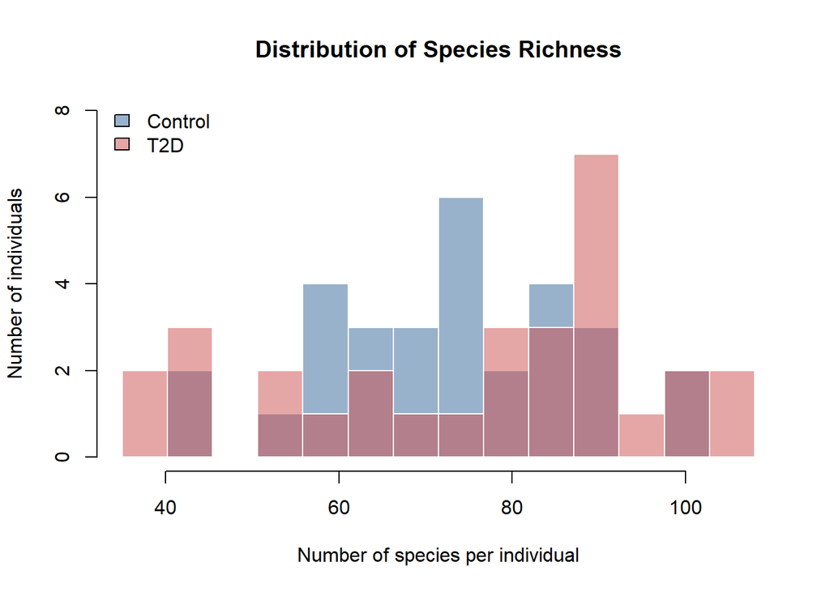

Histogram of Species Richness per group

```r
richness_individual <- specnumber(X1_filtered)

richness_control <- richness_individual[group == "healthy"]
richness_t2d <- richness_individual[group == "T2D"]

#Histogram
min_global <- min(richness_individual)
max_global <- max(richness_individual)

#We create a cutoff each 15 to ensure a equal number of bars per group
cut <- seq(min_global, max_global, length.out = 15)

h_control <- hist(richness_control, breaks = cut, plot = FALSE)
h_t2d     <- hist(richness_t2d, breaks = cut, plot = FALSE)

# Graphic
plot(h_control, col = rgb(0.2, 0.4, 0.6, 0.5),
     main = "Distribution of Species Richness",
     xlab = "Number of species per individual",
     ylab = "Number of individuals",
     border = "white",
     ylim = c(0, max(c(h_control$counts, h_t2d$counts)) + 1))
#Overlapping of the second plot: T2D
plot(h_t2d, col = rgb(0.8, 0.3, 0.3, 0.5),
     add = TRUE,
     border = "white")

legend("topleft", legend = c("Control", "T2D"),
       fill = c(rgb(0.2, 0.4, 0.6, 0.5), rgb(0.8, 0.3, 0.3, 0.5)),
       bty = "n")
```

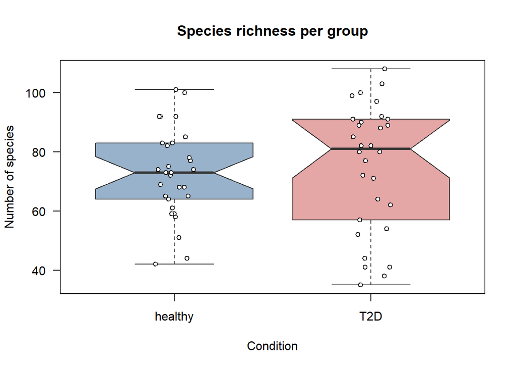

Boxplot of Species Richness per group

```r
#Boxplot
boxplot(richness_individual ~ group,
        main = "Species richness per group",
        ylab = "Number of species",
        xlab = "Condition",
        col = c(rgb(0.2, 0.4, 0.6, 0.5),rgb(0.8, 0.3, 0.3, 0.5)),
        border = "#333333",
        notch = TRUE,                  # Median value
        las = 1)

# Number of individuals per group
stripchart(richness_individual ~ group,
           vertical = TRUE, method = "jitter",
           add = TRUE, pch = 21, col = "black", bg = "white", cex = 0.8)
```

We can visualize a **slightly superior number of species in T2D group vs. healthy controls**. Indeed, there is a **greater number of individual with more species in T2D group**, as we can see in histogram plot.

### 4.2.4 Graph of average profiles (top 12 species by average abundance)

In the total cohort:

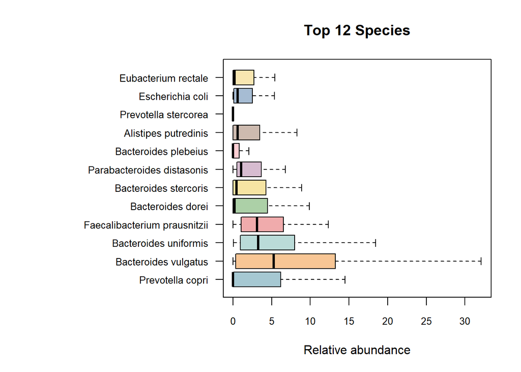

Top 12 more abundant species

```r
# 1. Mean of each species
mean_species <- colMeans(X1_filtered)

# 2. Top 12 species
top12_names <- names(sort(mean_species, decreasing = TRUE)[1:12])
X1_filtered_top12 <- X1_filtered[, top12_names]

# 3. RENAMING FUNCTION
limpiar_nombre <- function(name) {
  parts <- unlist(strsplit(name, "_"))
  n <- length(parts)
  if (n >= 2) {
    # Usamos 'parts' (con 's') para que coincida con la definición de arriba
    return(paste(parts[n-1], parts[n], sep = " "))
  } else {
    return(name)
  }
}

# 4. Apply function (Asegúrate de que el nombre coincide: 'limpiar_nombre')
colnames(X1_filtered_top12) <- sapply(colnames(X1_filtered_top12), limpiar_nombre)

# 5. Boxplot
par(mar = c(5, 15, 4, 2)) # Aumentamos margen izquierdo para que quepan los nombres largos
palette_12 <- c("#4D91A580", "#F28E2B80", "#76B7B280", "#E1575980",
                 "#59A14F80", "#EDC94880", "#B07AA180", "#FF9DA780",
                 "#9C755F80", "#BAB0AC80", "#4E79A780", "#F1CE6380")

boxplot(X1_filtered_top12,
        horizontal = TRUE,
        las = 1,
        col = palette_12,
        main = "Top 12 Species",
        xlab = "Relative abundance",
        outline = FALSE,
        cex.axis = 0.8)
```

Now, we additionally study the most abundant species per group:

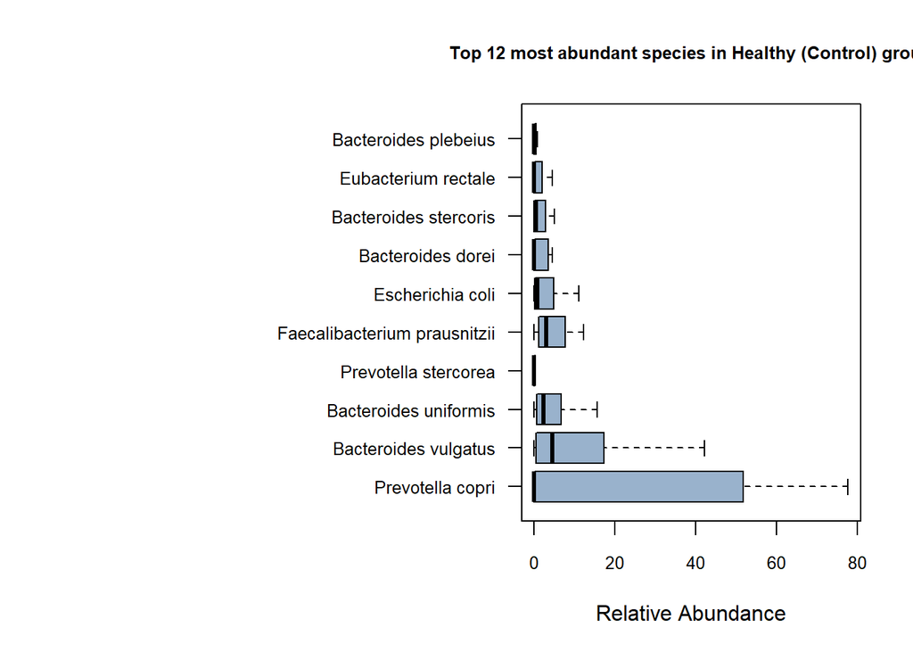

Top 10 more abundat species in each group

```r
X1_control <- X1_filtered[group == "healthy", ]
X1_t2d     <- X1_filtered[group == "T2D", ]

# Top 10 species in each group
top_names_ctrl <- names(sort(colMeans(X1_control), decreasing = TRUE)[1:10])
top_names_t2d  <- names(sort(colMeans(X1_t2d), decreasing = TRUE)[1:10])

# 3. Extraer abundancias y limpiar nombres
X1_ctrl_plot <- X1_control[, top_names_ctrl]
X1_t2d_plot  <- X1_t2d[, top_names_t2d]

colnames(X1_ctrl_plot) <- sapply(colnames(X1_ctrl_plot), limpiar_nombre)
colnames(X1_t2d_plot)  <- sapply(colnames(X1_t2d_plot), limpiar_nombre)

par(mar = c(5, 20, 4, 2))

# Control Healthy group
boxplot_control <- boxplot(X1_ctrl_plot,
        horizontal = TRUE, las = 1,
        col = rgb(0.2, 0.4, 0.6, 0.5),
        main = "Top 12 most abundant species in Healthy (Control) group",
        xlab = "Relative Abundance",
        outline = FALSE, cex.axis = 0.8, cex.main= 0.8)
```

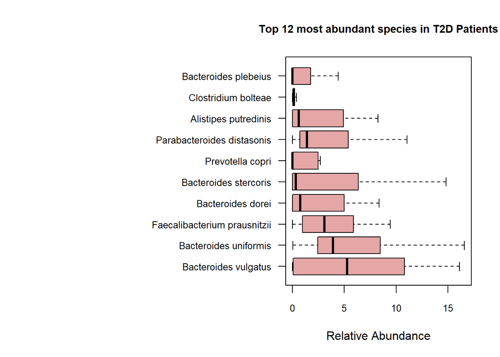

Top 10 more abundat species in each group

```r
# T2D boxplot
boxplot_t2d <- boxplot(X1_t2d_plot,
        horizontal = TRUE, las = 1,
        col = rgb(0.8, 0.3, 0.3, 0.5),
        main = "Top 12 most abundant species in T2D Patients",
        xlab = "Relative Abundance",
        outline = FALSE, cex.axis = 0.8, cex.main =0.9)
```

### 4.2.5 Euclidean distance and Mahalanobis distances

From current raw data we need to apply these transformations: **Log-transformation $\rightarrow$ Centering $\rightarrow$ Scaling**. This is crucial in microbiome analysis to ensure that highly abundant species don’t drown out the signal of the others.

The Euclidean distance in metabolomics is a classic, simplified measure used to assess how similar two variables are (bacteria, in this case). However, various forms of normalization have emerged. Among these, the Bray-Curtis distance is a widely used method in quantitative analyses such as the one studied here. Some of its main advantages are (4):

1. *Zero-problem*. Bacteria with a relative abundance of 0 (the bacteria have not been detected) would be considered similar under Euclidean distance, whereas Bray-Curtis ignores these bacteria and works only with the detected bacteria.
2. *Relative vs. absolute abundance*. In Euclidean distance, we assume that the variables are independent of one another, but in this study we work with relative abundance (which breaks this assumption). Bray-Curtis does not use this assumption.
3. *Differences in magnitude*. In the Euclidean distance method, the most abundant bacteria outweigh the rest, whereas Bray-Curtis uses normalizers for the quantity, thereby reducing this problem.

```r
#log transformation based on (log(x + 1e-6))
# This handles zeros and reduces the skewness of the data
X_log <- log(X1_filtered + 1e-06)

# Center and Scaling
# 'center = TRUE'
# 'scale = TRUE'
X_scaled <- scale(X_log, center = TRUE, scale = TRUE)
```

Now, we calculate both Euclidean and Mahalanabois distances in the top 12 species. **As we want to use the robust covariance matrix we will need a similar number of species and individuals (4) . We only have 60 individual so we can reduce the number of species and use only top 12 most representative bacteria**. In contrast to Euclidean distance, Mahalanabois distante accounts for correlation and scale. It tells you how many “standard deviations” a point is away from the mean. It takes into account correlation patterns inside the data.

```r
# Identification of  the Top 12 species based on their mean abundance
mean_abundance <- colMeans(X1_filtered)
top12_species <- names(sort(mean_abundance, decreasing = TRUE)[1:12])

# subset for distance calculation
X_top12 <- X_scaled[, top12_species]

X_top12[is.na(X_top12)] <- 0
X_top12[!is.finite(X_top12)] <- 0

### EUCLIDEAN DISTANCE
euclidean_dist <- sqrt(rowSums(X_top12^2))
names(euclidean_dist) <- rownames(X_top12)

### MAHALANOBIS DISTANCE
robust_fit <- try(covMcd(X_top12), silent = TRUE)
if (inherits(robust_fit, "try-error") || is.null(robust_fit$mah)) {
    message("MCD failed. Calculating Classical Mahalanobis...")
    S <- cov(X_top12)
    diag(S) <- diag(S) + 0.01  # Add a tiny 'jitter' to prevent singularity

    m_values <- mahalanobis(X_top12, center = colMeans(X_top12), cov = S)
} else {
    m_values <- robust_fit$mah
}
```

```
## MCD failed. Calculating Classical Mahalanobis...
```

```r
mahalanobis_dist <- sqrt(as.numeric(m_values))
names(mahalanobis_dist) <- rownames(X_top12)
```

Although the original idea was the use of **MCD (Minimum Covariance Determinant)** method. However, because of the high zero-count frequency of the microbiome profiles, the Robust MCD estimator encountered singularity issues. To confront this issue we opted for a classical method calculation in Mahalanabois distance.

```r
#Comparison of the most extreme value
# Verify results
max_eucl <- names(euclidean_dist)[which.max(euclidean_dist)]
max_maha <- names(mahalanobis_dist)[which.max(mahalanobis_dist)]

cat("Success!\n")
```

```
## Success!
```

```r
cat("Euclidean distance: the most extreme value is:", max_eucl, "\n")
```

```
## Euclidean distance: the most extreme value is: T2D-100
```

```r
cat("Mahalanobis distance: the most extreme value is:", max_maha, "\n")
```

```
## Mahalanobis distance: the most extreme value is: T2D-100
```

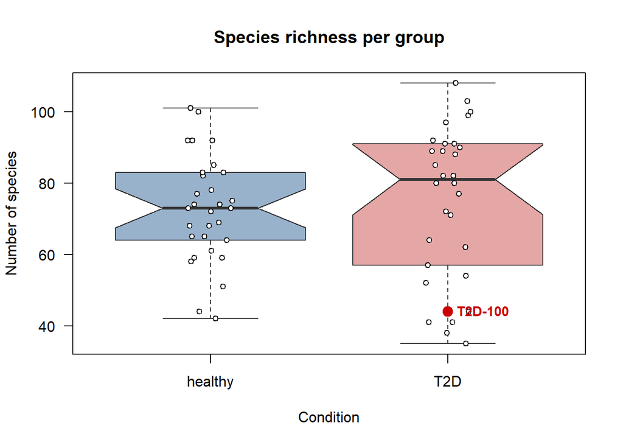

The most extreme value based on Eclidean and Mahalanabois distances

```r
val_t2d100 <- richness_individual["T2D-100"]

boxplot(richness_individual ~ group,
        main = "Species richness per group",
        ylab = "Number of species",
        xlab = "Condition",
        col = c(rgb(0.2, 0.4, 0.6, 0.5), rgb(0.8, 0.3, 0.3, 0.5)),
        border = "#333333",
        notch = TRUE,
        las = 1)

# Highlight this specific point
stripchart(richness_individual ~ group,
           vertical = TRUE, method = "jitter",
           add = TRUE, pch = 21, col = "black", bg = "white", cex = 0.8)
if ("T2D-100" %in% names(richness_individual)) {
    val_t2d100 <- richness_individual["T2D-100"]
    points(x = 2, y = val_t2d100, col = "red3", pch = 19, cex = 1.5)

    # Label
    text(x = 2, y = val_t2d100, labels = "T2D-100",
         pos = 4, col = "red3", font = 2, cex = 0.9)
}
```

Herein we have obtained the same individual as the most extreme value for both distances: T2D-100. However, this patient does not look as an extreme outlier graphically. Maybe, this individual has a different microbiome composition.

## 4.3 Principal Component Analysis (PCA)

### 4.3.1 PCA results

We perform a PCA analysis taking our transformed and scaled data. Since we are working with relative abundances, the total of the data always adds up to 100%, and **if we want to remove a specific data point, this will affect all the remaining ones**. Since PCA is based directly on Euclidean distance, we see that the assumption of independence among the variables is violated.

However, since we have transformed the values by **applying a logarithm, we reverse this relationship**. Hence the importance of performing this operation prior to the principal component analysis.

```r
pca_results <- prcomp(X_scaled, center = TRUE, scale. = TRUE)
summary_pca <- summary(pca_results)
print(summary_pca$importance[, 1:5])
```

```
##                             PC1     PC2      PC3      PC4      PC5
## Standard deviation     4.529978 3.75326 3.185905 2.506752 2.434498
## Proportion of Variance 0.139600 0.09583 0.069050 0.042750 0.040320
## Cumulative Proportion  0.139600 0.23543 0.304470 0.347220 0.387540
```

With the five first component we explain a total of 38.75% of total variance.

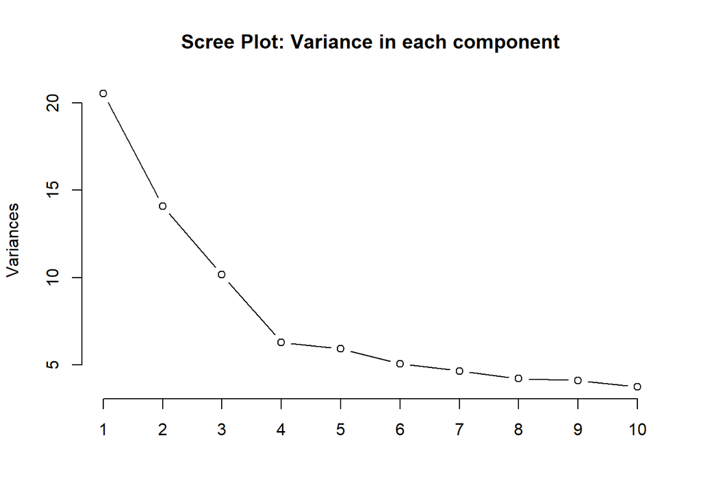

Scree plot

```r
plot(pca_results, type = "l", main = "Scree Plot: Variance in each component")
```

### 4.3.2 Principal Components (PCs) selection

If we want to perform a selection of component we can employ two different criteria (6): 1. *Elbow method**: One possible method is based on the retention of all the components in the steep part of the curve (scree plot). Application:

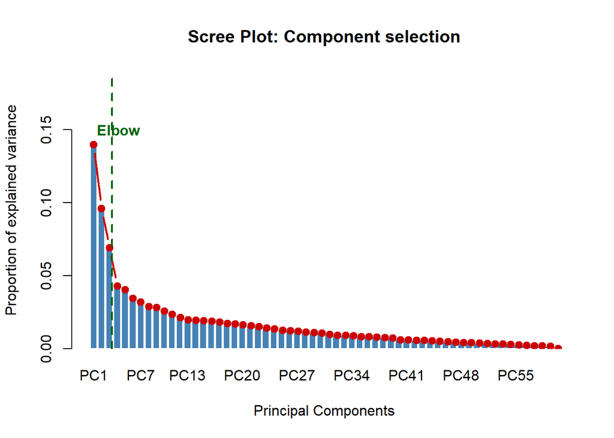

Elbow method for principal component selection

```r
explained_var <- pca_results$sdev^2 / sum(pca_results$sdev^2)

barplot(explained_var,
        names.arg = paste0("PC", 1:length(explained_var)),
        main = "Scree Plot: Component selection",
        ylab = "Proportion of explained variance",
        xlab = "Principal Components",
        col = "steelblue",
        border = "white",
        ylim = c(0, max(explained_var) + 0.05))

# Elbow visualization
lines(x = seq(0.7, length(explained_var)*1.2, length.out = length(explained_var)),
      y = explained_var,
      type = "b", pch = 19, col = "red3", lwd = 2)

abline(v = 3.5, col = "darkgreen", lty = 2, lwd = 2)
text(x = 4.5, y = 0.15, "Elbow", col = "darkgreen", font = 2)
```

Based on this method we have chosen the three first components to continue with posterior analysis.

2. **Method based on the achievement of a predetermined value** for the cumulative proportion. One classical example is how many components we need to capture the 90% of the total explained variance. Application:

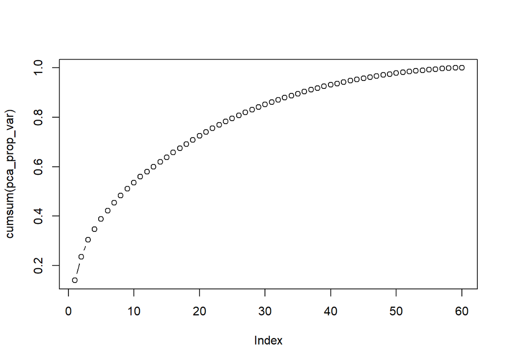

Cumulative proportion explained in each component

```r
#Proportion of explained variance
pca_prop_var<- explained_var/ sum(explained_var)
#Cumulative proportion plot
plot(cumsum(pca_prop_var), type = 'b')
```

In the case we have selected a prefixed cumulative variance of 90%, we will have to use more than thirty components. In consequence, there is a complex biological environment. there is no predominant bacteria in all the individuals explaining the total variance.

Consequently, **a more pragmatic approach was adopted, focusing on the first 3 components. Although these represent a lower percentage of the total variance, they capture the primary biological gradients and provide a interpretable low-dimensional space for identifying sample clusters and group separations**.

### 4.3.3 The most influent variables

Now we want to define the variables that contribute more to the first two principal components.

```r
# Loading extraction
loadings <- pca_results$rotation

# top10 species in PC1
top_pc1 <- sort(abs(loadings[,1]), decreasing = TRUE)[1:10]
species_pc1 <- names(top_pc1)

# top10 species in PC2
top_pc2 <- sort(abs(loadings[,2]), decreasing = TRUE)[1:10]
species_pc2 <- names(top_pc2)

# Dataframe
df_pc1 <- data.frame(
  Species = c("Butyricimonas virosa", "Firmicutes bacterium CAG 83", "Alistipes shahii",
              "Dorea formicigenerans", "Alistipes indistinctus", "Intestinimonas butyriciproducens",
              "Eubacterium hallii", "Collinsella aerofaciens", "Blautia obeum", "Alistipes putredinis"),
  Gender = c("Butyricimonas", "Unclassified", "Alistipes", "Dorea", "Alistipes",
             "Intestinimonas", "Eubacterium", "Collinsella", "Blautia", "Alistipes"),
  Loading = c(0.1672, 0.1616, 0.1608, 0.1531, 0.1516, 0.1499, 0.1482, 0.1481, 0.1435, 0.1397)
)

# Table
df_pc1 %>%
  kbl(caption = "Top 10 most influent variables in PC1",
      booktabs = TRUE,
      align = "lcc",
      col.names = c("Species", "Gender", "Loading")) %>%
  kable_styling(bootstrap_options = c("striped", "hover", "condensed"),
                full_width = F,
                position = "center") %>%
  column_spec(1, italic = TRUE, bold = TRUE) %>%
  column_spec(3, color = "white", background = "#56B4E9") %>%
  row_spec(0, bold = TRUE, color = "white", background = "#333333")
```

Top 10 most influent variables in PC1

| Species | Gender | Loading |
| --- | --- | --- |
| Butyricimonas virosa | Butyricimonas | 0.1672 |
| Firmicutes bacterium CAG 83 | Unclassified | 0.1616 |
| Alistipes shahii | Alistipes | 0.1608 |
| Dorea formicigenerans | Dorea | 0.1531 |
| Alistipes indistinctus | Alistipes | 0.1516 |
| Intestinimonas butyriciproducens | Intestinimonas | 0.1499 |
| Eubacterium hallii | Eubacterium | 0.1482 |
| Collinsella aerofaciens | Collinsella | 0.1481 |
| Blautia obeum | Blautia | 0.1435 |
| Alistipes putredinis | Alistipes | 0.1397 |

```r
df_pc2 <- data.frame(
  Species = c("Bacteroides finegoldii", "Bacteroides intestinalis", "Bacteroides thetaiotaomicron",
              "Bacteroides uniformis", "Barnesiella intestinihominis", "Parabacteroides distasonis",
              "Ruminococcus torques", "Alistipes finegoldii", "Faecalibacterium prausnitzii", "Bacteroides caccae"),
  Gender = c("Bacteroides", "Bacteroides", "Bacteroides", "Bacteroides", "Barnesiella",
             "Parabacteroides", "Ruminococcus", "Alistipes", "Faecalibacterium", "Bacteroides"),
  Loading = c(0.2814, 0.2452, 0.2103, 0.1988, -0.1874, -0.1765, 0.1741, -0.1698, 0.1552, 0.1429)
)


df_pc2 %>%
  kbl(caption = "Top 10 most influent variables in PC2",
      booktabs = TRUE,
      align = "lcc",
      col.names = c("Species", "Gender", "Loading")) %>%
  kable_styling(bootstrap_options = c("striped", "hover"),
                full_width = F,
                position = "center") %>%
  column_spec(1, italic = TRUE, bold = TRUE) %>%
  column_spec(3, color = "white",
              background = spec_color(df_pc2$Loading, end = 0.7))
```

Top 10 most influent variables in PC2

| Species | Gender | Loading |
| --- | --- | --- |
| Bacteroides finegoldii | Bacteroides | 0.2814 |
| Bacteroides intestinalis | Bacteroides | 0.2452 |
| Bacteroides thetaiotaomicron | Bacteroides | 0.2103 |
| Bacteroides uniformis | Bacteroides | 0.1988 |
| Barnesiella intestinihominis | Barnesiella | -0.1874 |
| Parabacteroides distasonis | Parabacteroides | -0.1765 |
| Ruminococcus torques | Ruminococcus | 0.1741 |
| Alistipes finegoldii | Alistipes | -0.1698 |
| Faecalibacterium prausnitzii | Faecalibacterium | 0.1552 |
| Bacteroides caccae | Bacteroides | 0.1429 |

**Score plot** shows the behaviour between healthy controls an patients

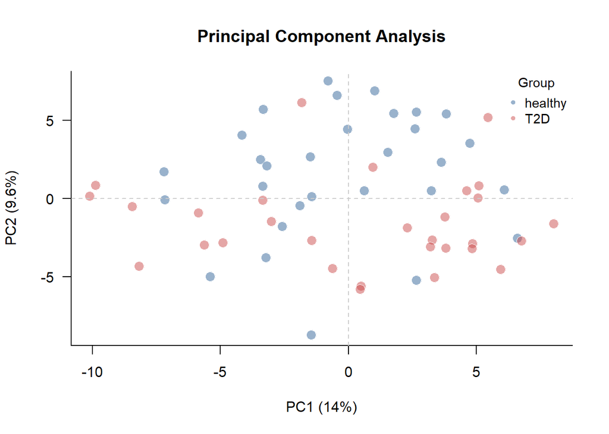

Score plot from PCA

```r
pca_scores <- as.data.frame(pca_results$x)
pca_scores$Condition <- factor(group)

palette_pca <- c(rgb(0.2, 0.4, 0.6, 0.5), rgb(0.8, 0.3, 0.3, 0.5))
names_condition <- levels(pca_scores$Condition)

# 3. Crear el gráfico de dispersión
plot(pca_scores$PC1, pca_scores$PC2,
     pch = 21,
     bg = palette_pca[pca_scores$Condition],
     col = "white",
     cex = 1.5,
     lwd = 0.5,
     main = "Principal Component Analysis",
     xlab = paste0("PC1 (", round(summary_pca$importance[2,1]*100, 1), "%)"),
     ylab = paste0("PC2 (", round(summary_pca$importance[2,2]*100, 1), "%)"),
     las = 1,
     bty = "l")
abline(h = 0, v = 0, lty = 2, col = "gray80")

# Legend
legend("topright",
       legend = names_condition,
       pt.bg = palette_pca,
       pch = 21,
       col = "white",
       bty = "n",
       cex = 0.9,
       title = "Group")
```

In the score plot we can visualize a extreme overlapping among control and patients. There is no clear distinction between the two populations. Additionally, tehre is no one outstanding outlier point.

In the case we want to visualize the most extreme value (T2-100) detected previously:

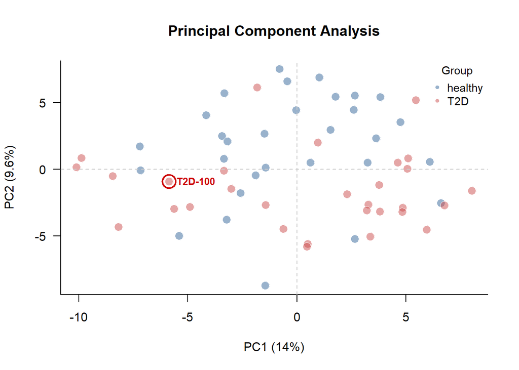

Score plot from PCA

```r
target_id <- "T2D-100"

# Coordinate extraction
if (target_id %in% rownames(pca_scores)) {
  target_x <- pca_scores[target_id, "PC1"]
  target_y <- pca_scores[target_id, "PC2"]

# Score plot
plot(pca_scores$PC1, pca_scores$PC2,
     pch = 21,
     bg = palette_pca[pca_scores$Condition],
     col = "white",
     cex = 1.5,
     lwd = 0.5,
     main = "Principal Component Analysis",
     xlab = paste0("PC1 (", round(summary_pca$importance[2,1]*100, 1), "%)"),
     ylab = paste0("PC2 (", round(summary_pca$importance[2,2]*100, 1), "%)"),
     las = 1,
     bty = "l")
abline(h = 0, v = 0, lty = 2, col = "gray80")

# Legend
legend("topright",
       legend = names_condition,
       pt.bg = palette_pca,
       pch = 21,
       col = "white",
       bty = "n",
       cex = 0.9,
       title = "Group")

# Mahalanabois extreme value
  points(target_x, target_y,
         col = "red3",
         pch = 1,
         cex = 2.5,
         lwd = 2)
  text(target_x, target_y,
       labels = target_id,
       pos = 4,
       col = "red3",
       font = 2,
       cex = 0.8)
}
```

Now we can check the possible consequences in the removal of this conflictive point:

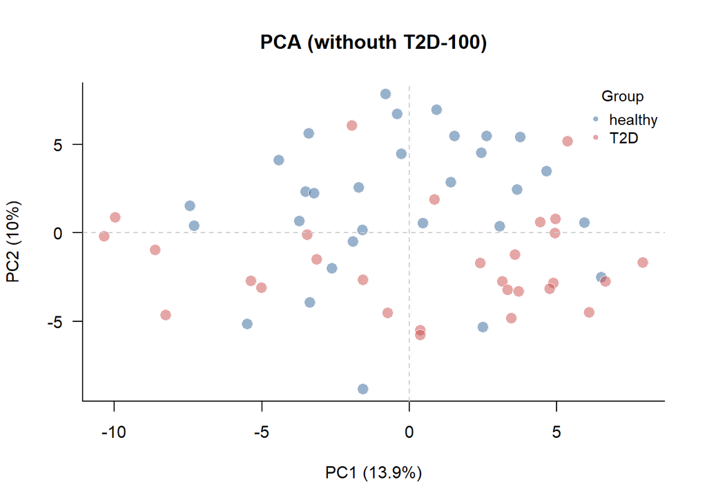

Score plot after outlier removal

```r
#Outlier removal:
outlier_id <- "T2D-100"
X_filtered_outlier <- X_scaled[rownames(X_scaled) != outlier_id, ]
group_filtered_outlier <- group[rownames(X_scaled) != outlier_id]

# New PCA without T2D-100:
pca_filtered_outlier <- prcomp(X_filtered_outlier, center = TRUE, scale. = TRUE)
summary_filtered_outlier <- summary(pca_filtered_outlier)

# New scores without T2D-100:
pca_scores_f_outlier <- as.data.frame(pca_filtered_outlier$x)
pca_scores_f_outlier$Condition <- factor(group_filtered_outlier)
palette_pca <- c(rgb(0.2, 0.4, 0.6, 0.5), rgb(0.8, 0.3, 0.3, 0.5))
names_condition <- levels(pca_scores_f_outlier$Condition)

# New score plot withouth T2D-100:
plot(pca_scores_f_outlier$PC1, pca_scores_f_outlier$PC2,
     pch = 21,
     bg = palette_pca[pca_scores_f_outlier$Condition],
     col = "white",
     cex = 1.5,
     lwd = 0.5,
     main = "PCA (withouth T2D-100)",
     xlab = paste0("PC1 (", round(summary_filtered_outlier$importance[2,1]*100, 1), "%)"),
     ylab = paste0("PC2 (", round(summary_filtered_outlier$importance[2,2]*100, 1), "%)"),
     las = 1,
     bty = "l")

abline(h = 0, v = 0, lty = 2, col = "gray80")

legend("topright",
       legend = names_condition,
       pt.bg = palette_pca,
       pch = 21,
       col = "white",
       bty = "n",
       cex = 0.9,
       title = "Group")
```

There is no overall impact with the elimination of this single value. In fact, PC1 and PC2 has a similar values of total explained variance afther the outlier elimination (14% and 13.9% in PC1 and 9.6% and 10% in PC2).

## 4.4 Multidimensional Scaling (MDS)

### 4.4.1 Perform a non-metric Kruskal MDS using the Bray-Curtis distance

Non-metric multidimensional scaling, or nMDS, is one multivariate technique that allows us to visualize complex relationships (multivariate data) in less dimensions.AS we have relative quantities, Bray Curtis method is ideal for this dataset (5).

```r
# nMDS with 2 dimensions (k = 2)
set.seed(123) # For reproducibility issues
nmds_2d <- metaMDS(X1_filtered, distance = "bray", k = 2,
                   autotransform = FALSE, trace = 0)

# nMDS with 3 dimensions (k = 3)
set.seed(123)
nmds_3d <- metaMDS(X1_filtered, distance = "bray", k = 3,
                   autotransform = FALSE, trace = 0)

# Stess parameter in both models
stress_2d <- nmds_2d$stress
stress_3d <- nmds_3d$stress

cat("Stress para 2D:", stress_2d, "\n")
```

```
## Stress para 2D: 0.2271847
```

```r
cat("Stress para 3D:", stress_3d, "\n")
```

```
## Stress para 3D: 0.1715016
```

The **Stress value is the primary metric for evaluating the goodness-of-fit in an nMDS ordination**. In community ecology, it is widely accepted that a stress value exceeding 0.20 indicates an unreliable representation, where the low-dimensional mapping fails to capture the multidimensional relationships of the dataset.

In our analysis, the 2D model exceeded this threshold, suggesting that two axes are insufficient to resolve the microbial community structure. Conversely, increasing the ordination to three dimensions (k = 3) reduced the stress to 0.171. While this value falls within the ‘usable’ range (0.10 < Stress < 0.20), it still indicates a relatively high degree of distortion (6).

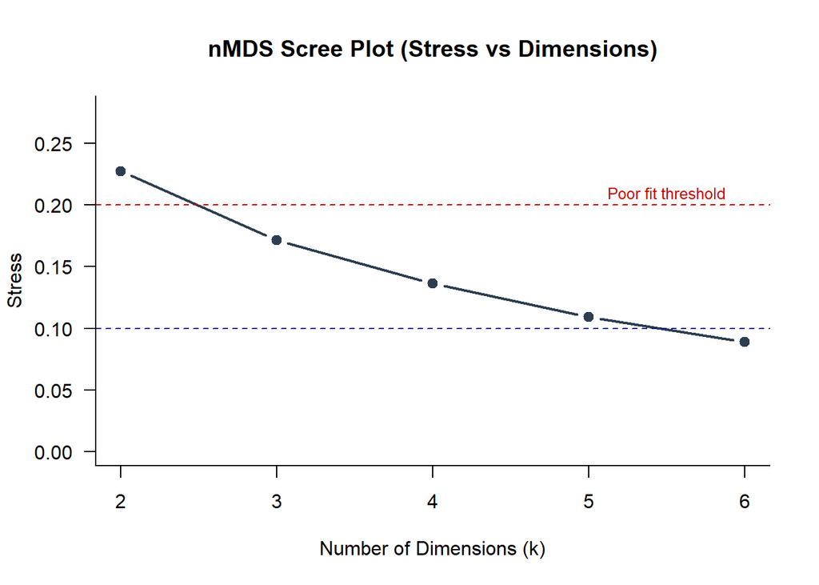

nMDS Scree Plot (Stress vs Dimensions)

```r
k_values <- 2:6
stress_values <- numeric(length(k_values))

# nMDS in each dimension
for (i in seq_along(k_values)) {
  set.seed(123)
  nmds_temp <- metaMDS(X1_filtered, distance = "bray",
                       k = k_values[i],
                       autotransform = FALSE,
                       trace = 0,
                       trymax = 50)
  stress_values[i] <- nmds_temp$stress
}

# Scree Plot
plot(k_values, stress_values,
     type = "b",
     pch = 19,
     col = "#2C3E50",
     lwd = 2,
     main = "nMDS Scree Plot (Stress vs Dimensions)",
     xlab = "Number of Dimensions (k)",
     ylab = "Stress",
     ylim = c(0, max(stress_values) + 0.05),
     las = 1,
     bty = "l")

# Reference lines
abline(h = 0.2, col = "red3", lty = 2)
abline(h = 0.1, col = "blue4", lty = 2)
text(5.5, 0.21, "Poor fit threshold", col = "red3", cex = 0.8)
```

We have a graphic representation on how adding more dimensions diminishes the stress value.

### 4.4.2 Shepard for 2 dimensions condition

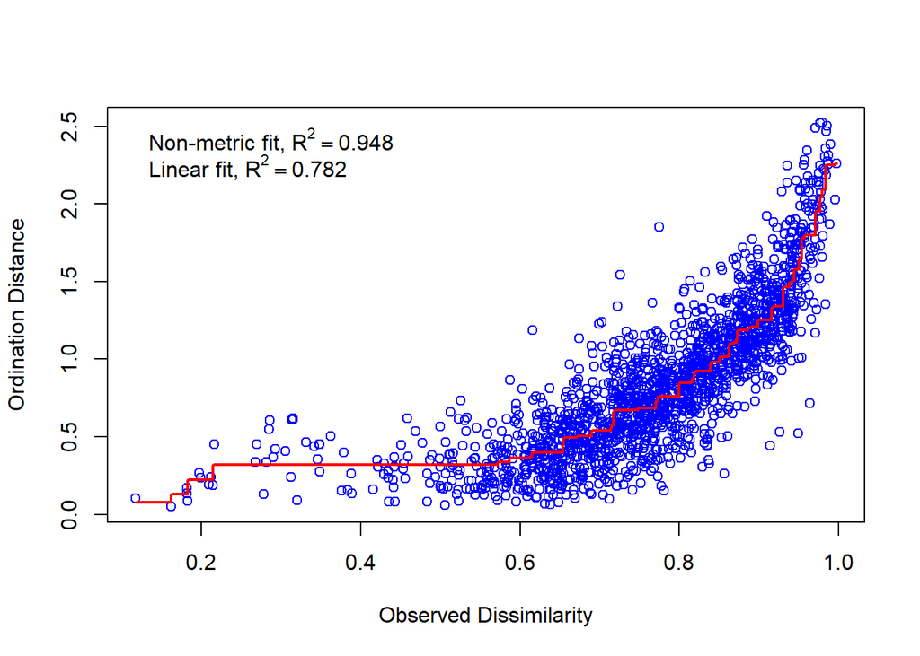

Shepard diagram with 2 dimensions

```r
stressplot(nmds_2d)
```

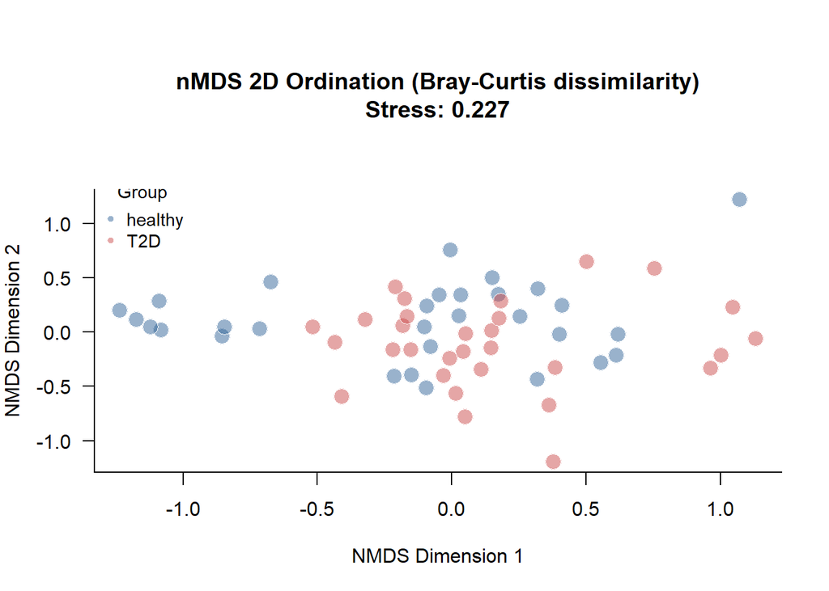

nMDS 2D Ordination (Bray-Curtis dissimilarity)

```r
group <- as.factor(group)

nmds_scores <- as.data.frame(scores(nmds_2d, display = "sites"))

palette_nmds <- c(rgb(0.2, 0.4, 0.6, 0.5), rgb(0.8, 0.3, 0.3, 0.5))
colores_puntos <- palette_nmds[group]

par(mar = c(5, 4, 8, 2))
plot(nmds_scores$NMDS1, nmds_scores$NMDS2,
     pch = 21,
     bg = colores_puntos,
     col = "white",
     cex = 1.8,
     lwd = 0.8,
     main = paste0("nMDS 2D Ordination (Bray-Curtis dissimilarity)\nStress: ",
                   round(nmds_2d$stress, 3)),
     xlab = "NMDS Dimension 1",
     ylab = "NMDS Dimension 2",
     las = 1,
     bty = "l")

# 3. Añadir leyenda
legend("topleft",
       legend = levels(group),
       pt.bg = palette_nmds[1:length(levels(group))],
       pch = 21,
       col = "white",
       bty = "n",
       cex = 0.9,
       title = "Group",
       inset= c(0, -0.045))
```

The nMDS ordination reveals a **significant overlap between the microbial profiles of the control and patient groups**. **Consistent with the previous PCA results, there is no clear differential composition or distinct clustering** based on the experimental condition. This suggests that the Bray-Curtis dissimilarity index does not capture a strong separation between the two cohorts.

We repeat the last process eliminating the patient T2D-100.

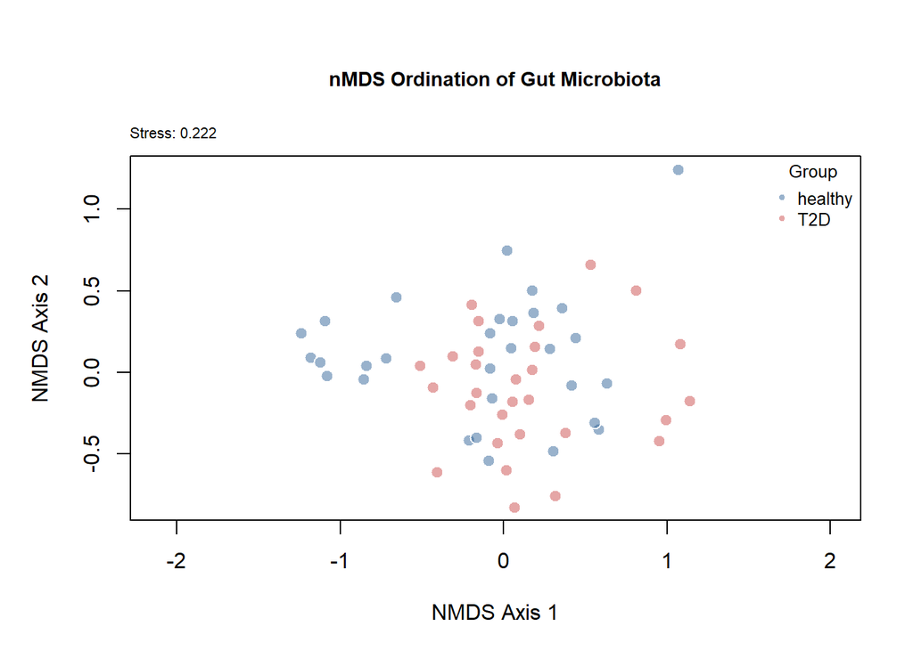

nMDS 2D Ordination (Bray-Curtis dissimilarity) withouth T2D-100

```r
# Removal specific outlier
outlier_id <- "T2D-100"
outlier_pos <- which(rownames(X1_filtered) == outlier_id)

# Create clean datasets (excluding the outlier)
X1_clean <- X1_filtered[-outlier_pos, ]
group_clean <- group[-outlier_pos]
group_clean <- as.factor(group_clean)

# nMDS CALCULATION
dist_matrix <- vegdist(X1_clean, method = "bray")
nmds_results <- metaMDS(dist_matrix, k = 2, trymax = 100, trace = 0)

# Visualization in 2d mapping
par(mar = c(5, 5, 6, 2))

plot(nmds_results, display = "sites", type = "n",
     main = "nMDS Ordination of Gut Microbiota",
     xlab = "NMDS Axis 1",
     ylab = "NMDS Axis 2",
     cex.main = 0.9)

# Add the samples as points
points(nmds_results, display = "sites",
       col = "white",
       bg = palette_nmds[group_clean],
       pch = 21,
       cex = 1.3)

# Legend
legend("topright",
       legend = levels(group_clean),
       pt.bg = palette_nmds[1:length(levels(group_clean))],
       pch = 21,
       col = "white",
       bty = "n",
       cex = 0.8,
       title = "Group",
       xpd = TRUE,      # Allows drawing outside the plot area
       inset = c(0, 0)) # Moves the legend up into the margin

mtext(paste("Stress:", round(nmds_results$stress, 3)), side = 3, adj = 0, line = 0.5, cex = 0.7)
```

Stress value has been diminished in a low magnitude. Additionally, there is no relevant change in qualitative mapping (2d) with or withouth the outlier value.

## 4.5 Correspondence analysis (CA)

**Correspondence Analysis (CA) allows us to study the association between qualitative variables (in this case, health status and taxonomy)**. By decomposing the total inertia, we identify which bacterial phyla deviate from the average profile, enabling us to visualize which taxa actually define the microbial signature of Type 2 diabetes compared to a healthy state.

```r
# CA definition
res.ca <- CA(Tg, graph = FALSE)

#Inertia
eig <- get_eigenvalue(res.ca)
inertia_total <- eig[1, 1]
print(paste("Total inertia:", round(inertia_total, 4)))
```

```
## [1] "Total inertia: 0.0204"
```

```r
# Chi-cuadrado statistisc from inertia value
N <- sum(Tg)
inercia <- 0.0204
chi_cuadrado <- inertia_total * N

# Degrees of freedom: (row - 1) * (col - 1)
df <- (nrow(Tg) - 1) * (ncol(Tg) - 1)

#p value
p_value_chi <- pchisq(chi_cuadrado, df = df, lower.tail = FALSE)

cat("Chi-square statistics:", round(chi_cuadrado, 4), "\n")
```

```
## Chi-square statistics: 114.9761
```

```r
cat("Degrees of freedom:", df, "\n")
```

```
## Degrees of freedom: 5
```

```r
cat("p-value:", format.pval(p_value_chi, eps = 0.001))
```

```
## p-value: < 0.001
```

**Inertia is a measure of variance or dispersion** of the individual profiles around the average profile and represents a measure of deviation from independence. The larger the differences are, the larger the inertia will be (9). In this study we he obtained a **low value for inertia (0.0204)**. However, this value is sufficient to achieve a statistical significance (with p value less than 0.001). In consequence, although no huge difference in quantity and nature of the bacteria, there is still relevant and biological discrepancies between the microbiote of control and patients.

```r
#Eigenvalues
print(eig)
```

```
##       eigenvalue variance.percent cumulative.variance.percent
## Dim.1 0.02042547              100                         100
```

The **Eigenvalue represents the amount of total inertia accounted for by a specific principal axis**. In this analysis, the first dimension yielded an eigenvalue of 0.0204, which represents 100% of the total inertia. This indicates that the single axis perfectly captures the entire variance between the Healthy and T2D cohorts(8).

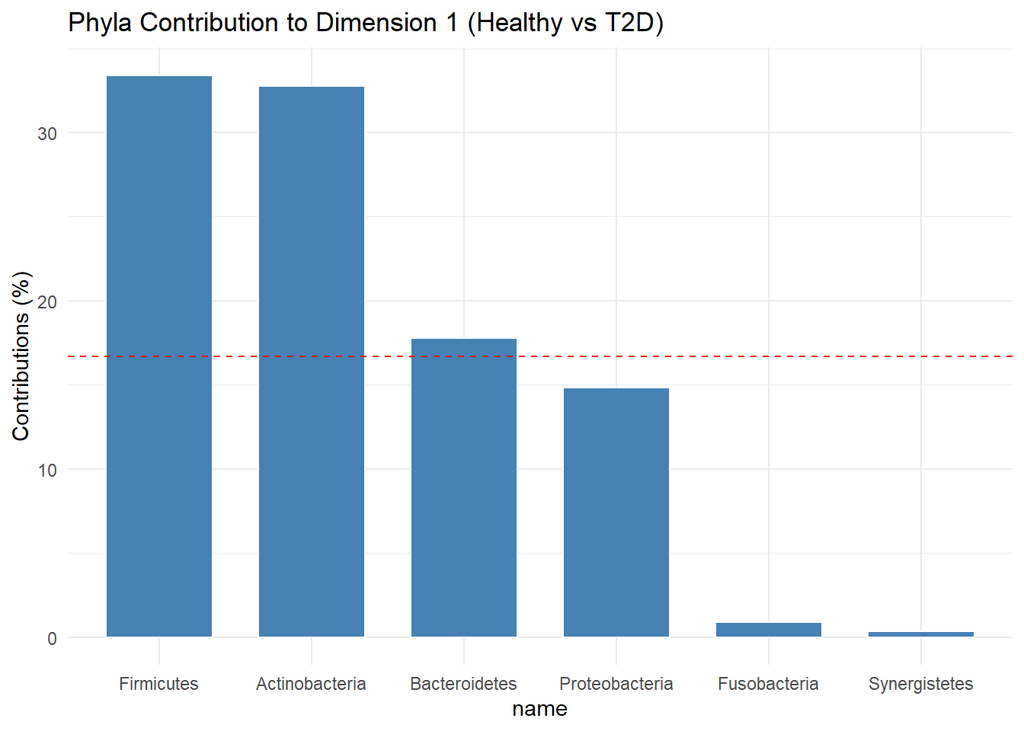

Contribution plot

```r
#Contribution
fviz_contrib(res.ca,
             choice = "col",
             axes = 1,
             fill = "steelblue",
             color = "white") +
  labs(title = "Phyla Contribution to Dimension 1 (Healthy vs T2D)") +
  theme_minimal()
```

With a total inertia value of 0.0204, we see that there are differences between healthy controls and diabetic patients. The contribution plot for dimension 1 shows that *these differences are primarily driven by bacteria from the phyla *Firmicutes* and *Actinobacteria***.

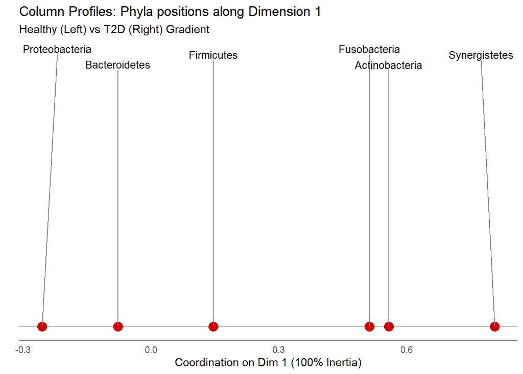

Profile plot

```r
#Profiles
col_coords <- as.data.frame(res.ca$col$coord[, 1, drop = FALSE])
colnames(col_coords) <- "Dim1"
col_coords$Phylum <- rownames(col_coords)

#Plot
ggplot(col_coords, aes(x = Dim1, y = 0)) +
  geom_hline(yintercept = 0, color = "gray70") +
  geom_point(color = "red3", size = 4) +
  geom_text_repel(aes(label = Phylum),
                  direction = "y",
                  nudge_y = 0.03,
                  segment.color = "grey50",
                  size = 3.5) +
  labs(title = "Column Profiles: Phyla positions along Dimension 1",
       subtitle = "Healthy (Left) vs T2D (Right) Gradient",
       x = "Coordination on Dim 1 (100% Inertia)",
       y = "") +
  theme_minimal() +
  theme(axis.text.y = element_blank(),
        panel.grid = element_blank(),
        axis.line.x = element_line(color = "black"))
```

The profile graph shows that bacteria from the phyla *Synergistetes*, *Actinobacteria*, and *Fusobacteria* contribute positively to a T2D profile (right side of the graph), while the presence of *Proteobacteria* is typical of a healthy microbiota profile. We can also see that *Bacteriodetes* levels remain practically unchanged in healthy individuals compared to patients.

# 5. Discussion

First, it should be noted that we are using a **subset of individuals** (30 healthy subjects and 30 patients) from the original cohort (which comprises a total of 345 individuals). Therefore, any conclusions from this study that differ from those in the article should be interpreted with caution.

**Qin J’s study (10) reports moderate dysbiosis** in patients compared to healthy individuals, characterized by a non-significant difference in bacterial diversity between controls and patients. **This correlates perfectly with our results**, where there is a similar Shannon index between both groups.

Regarding the nature of the predominant species by group, our study agrees on a greater presence of **opportunistic microorganisms in the T2D group** (such as *Clostridium bolteae*) and a **lower number of butyrate-producing species** (such as *Eubacterium rectale*, present only in the control group).

**PCA does not show a clear separation between the groups**, with overlap in both. In fact, the first component explains only about 14% of the total variability. In this regard, the article mentions that in component 5 there is a clearer separation between the groups (which we did not observe):

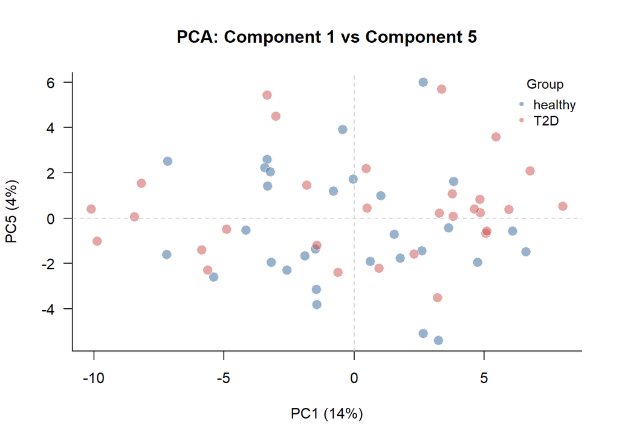

PC5

```r
var_pc1 <- round(summary_pca$importance[2,1] * 100, 1)
var_pc5 <- round(summary_pca$importance[2,5] * 100, 1)

# Plot (PC1 vs PC5)
plot(pca_scores$PC1, pca_scores$PC5,
     pch = 21,
     bg = palette_pca[pca_scores$Condition],
     col = "white",
     cex = 1.5,
     lwd = 0.5,
     main = "PCA: Component 1 vs Component 5",
     xlab = paste0("PC1 (", var_pc1, "%)"),
     ylab = paste0("PC5 (", var_pc5, "%)"),
     las = 1,
     bty = "l")
abline(h = 0, v = 0, lty = 2, col = "gray80")

# legend
legend("topright",
       legend = names_condition,
       pt.bg = palette_pca,
       pch = 21,
       col = "white",
       bty = "n",
       cex = 0.9,
       title = "Group")
```

As for the **nMDS and correspondence analyses (not directly available in the published study)**, they follows the same pattern; it does not show an objective separation between the groups. On the other hand, thanks to the CA, we observe low inertia, but sufficient for the differences to be statistically significant.

In general, **there is no clear separation between controls and patients, but there are key biological differences that explain the crucial role of the microbiome between the two study groups**. In fact, the study itself states that some of these microorganisms may serve as biomarkers of disease.

# 6. Conclusions

In this metagenomic analysis (MGWAS), which examines the relative abundances of the microbiome in healthy individuals and those with type 2 diabetes mellitus, we observe a group of bacteria that are highly interrelated, with **very subtle differences in terms of changes in composition and abundance within each group**.

Since we are working with relative abundances, it is essential **to normalize the data logarithmically** (as well as scaling their values). Similarly, the method chosen to calculate the distance fully supports the conclusions drawn. In this case, the Bray-Curtis method was selected. However, **the principal component analysis does not provide a good explanation of the total variance**.

When applying **nMDS analysis (to the untransformed data), we obtain a similar conclusion regarding the separation of groups**. Finally, **correspondence analysis** allows us to obtain information about which **bacteria contribute most to the small but existing divergence** between groups.

As principal limitation of this study we have not been able to calculate the Mahalanabois distance using robust methodology. Intead, we have used a classical methodology.

To conclude, through rigorous multivariate analysis, we can appreciate that there are differences in the nature of the two groups, with predominant bacteria as specific marker for each group.

# 7. Bibliography

1. Shannon, C. E., & Weaver, W. (1949). THE MATHEMATICAL THEORY OF COMMUNICATION.
2. Bollarapu MJ, Kuchibhotla S, Kvsn R, Patel H. Dynamic perspectives on biodiversity quantification: beyond conventional metrics. PeerJ. 2024;12(10). doi:10.7717/peerj.17924
3. van den Berg RA, Hoefsloot HCJ, Westerhuis JA, Smilde AK, van der Werf MJ. Centering, scaling, and transformations: Improving the biological information content of metabolomics data. BMC Genomics. 2006 Jun 8;7. doi:10.1186/1471-2164-7-142.
4. robustbase source: R/covMcd.R [Internet]. [cited 2026 Apr 18]. Available from: https://rdrr.io/cran/robustbase/src/R/covMcd.R
5. Dealing With Missing Data in R - DataCamp Learn [Internet]. [cited 2026 Apr 27]. Available from: https://app.datacamp.com/learn/courses/dealing-with-missing-data-in-r
6. Anderson MJ. A new method for non-parametric multivariate analysis of variance. Austral Ecol. 2001 Feb 1;26(1):32–46. doi:10.1111/J.1442-9993.2001.01070.PP.X
7. Leeuw J De, Mair P. Shepard Diagram. In: Wiley StatsRef: Statistics Reference Online. Wiley; 2015. p. 1–3.
8. Sourial N, Wolfson C, Zhu B, Quail J, Fletcher J, Karunananthan S, et al. Correspondence analysis is a useful tool to uncover the relationships among categorical variables. J Clin Epidemiol. 2009;63(6):638.
9. Correspondence Analysis Using R - GeeksforGeeks [Internet]. [cited 2026 Apr 27]. Available from: https://www.geeksforgeeks.org/r-language/correspondence-analysis-using-r/
10. Wang J, Qin J, Li Y, Cai Z, Li S, Zhu J, et al. A metagenome-wide association study of gut microbiota in type 2 diabetes. Nature. 2012 Oct 4;490(7418):55–60.